# Data Profiling project

## Data

Candidate financial summary without PAC breakdown (Election Cycle 2013-14) which is available here. Data dictionary for this data set may be found [here](http://www.fec.gov/finance/disclosure/metadata/DataDictionaryWEBL.shtml).

Reading the data in after downloading and unzipping it:

```r
columns <- c('CAND_ID', 'CAND_NAME', 'CAND_ICI', 'PTY_CD',
               'CAND_PTY_AFFILIATION', 'TTL_RECEIPTS', 'TRANS_FROM_AUTH',
               'TTL_DISB', 'TRANS_TO_AUTH', 'COH_BOP', 'COH_COP',
               'CAND_CONTRIB', 'CAND_LOANS', 'OTHER_LOANS', 'CAND_LOAN_REPAY',
               'OTHER_LOAN_REPAY', 'DEBTS_OWED_BY', 'TTL_IND_CONTRIB',
               'CAND_OFFICE_ST', 'CAND_OFFICE_DISTRICT', 'SPEC_ELECTION',
               'PRIM_ELECTION', 'RUN_ELECTION', 'GEN_ELECTION',
               'GEN_ELECTION_PERCENT', 'OTHER_POL_CMTE_CONTRIB',
               'POL_PTY_CONTRIB', 'CVG_END_DT', 'INDIV_REFUNDS',
               'CMTE_REFUNDS')

# Note to self: pipe-delimited gets really messed up without the quote = NULL!
df <- read.table('C:/Users/Paul/CUNY MSDA/IS607/IS607Projects/Data Profile/webl14.txt', header = FALSE,
                 sep = '|', col.names = columns, stringsAsFactors = FALSE,
                 na.strings = c('', 'NA'), quote = NULL)

# Ensure CVG_END_DT (Coverage End Date) is in POSIX format
library(lubridate)
df$CVG_END_DT <- mdy(df$CVG_END_DT)
```

## Profile

### General characteristics

This data set consists of 1784 rows of data, with 30 columns in total.

The variables definitions as follows:

- CAND_ID: Candidate identification
- CAND_NAME: Candidate name
- CAND_ICI: Incumbent/Challenger
- PTY_CD: Party code
- CAND_PTY_AFFILIATION: Affiliation
- TTL_RECEIPTS: Total receipts
- TRANS_FROM_AUTH: Transfers from authorized committees
- TTL_DISB: Total disbursements
- TRANS_TO_AUTH: Transfers to authorized committees
- COH_BOP: Beginning cash
- COH_COP: Ending cash
- CAND_CONTRIB: Contributions from candidate
- CAND_LOANS: Loans from candidate
- OTHER_LOANS: Other loans
- DEBTS_OWED_BY: Debts owed by candidate
- TTL_INDIV_CONTRIB: Total individual contributions
- CAND_OFFICE_ST: Candidate state
- CAND_OFFICE_DIST: Candidate district
- SPEC_ELECTION: Special election status
- PRIM_ELECTION: Primary election status
- RUN_ELECTION: Runoff election status
- GEN_ELECTION: General election status
- GEN_ELECTION_PERCENT: General election percentage of vote
- OTHER_POL_CMTE_CONTRIB: Contributions from other political committees
- POL_PTY_CONTRIB: Contributions from party committees
- CVG_END_DT: Coverage end date
- INDIV_REFUNDS: Refunds to individuals
- CMTE_REFUNDS: Refunds to committees

### Looking at variable characteristics: Data type, NAs, number of unique values

```r
df$TTL_RECEIPTS <- df$TTL_RECEIPTS - df$TRANS_TO_AUTH
df$TTL_DISB <- df$TTL_DISB - df$TRANS_FROM_AUTH
```

Second, we create a customized function inluding general characteristics about each variable.

```r
summary.function <- function(vector) {
  cat(sprintf("Column data type: %-10s", class(vector)))
  cat(sprintf('\nNumber of NA values: %-5i', sum(is.na(vector))))
  cat(sprintf('\nNumber of unique values: %-5i', length(unique(vector))), '\n')
  cat('Summary statistics:\n')
  print(summary(vector))
}

for (name in columns) {
  cat('\n\nVariable', name, '\n')
  summary.function(df[[name]])
}
```

```
##
##
## Variable CAND_ID
## Column data type: character
## Number of NA values: 0
## Number of unique values: 1784
## Summary statistics:
##    Length     Class      Mode
##      1784 character character
##
##
## Variable CAND_NAME
## Column data type: character
## Number of NA values: 0
## Number of unique values: 1767
## Summary statistics:
##    Length     Class      Mode
##      1784 character character
##
##
## Variable CAND_ICI
## Column data type: character
## Number of NA values: 14
## Number of unique values: 4
## Summary statistics:
##    Length     Class      Mode
##      1784 character character
##
##
## Variable PTY_CD
## Column data type: integer
## Number of NA values: 0
## Number of unique values: 3
## Summary statistics:
##    Min. 1st Qu.  Median    Mean 3rd Qu.    Max.
##    1.00    1.00    2.00    1.69    2.00    3.00
##
##
## Variable CAND_PTY_AFFILIATION
## Column data type: character
```

[output cut: 217 more lines]

```
## Column data type: numeric
## Number of NA values: 0
## Number of unique values: 516
## Summary statistics:
##    Min. 1st Qu.  Median    Mean 3rd Qu.    Max.
##   -9490       0       0    7920    2600 1100000
##
##
## Variable CMTE_REFUNDS
## Column data type: numeric
## Number of NA values: 0
## Number of unique values: 129
## Summary statistics:
##    Min. 1st Qu.  Median    Mean 3rd Qu.    Max.
##  -10000       0       0    2070       0  668000
```

Using this information, we can highlight any peculiarities about individual variables.

#### CAND_NAME (Candidate name)

Interestingly, the number of unique names is smaller than the total number of rows. To see which candidates show up more than once, we use the following code:

```r
df$CAND_NAME[duplicated(df$CAND_NAME)]
```

```
##  [1] "YOUNG, DAVID"             "BACHMANN, MICHELE"
##  [3] "BARR, BOB"                "COTTON, THOMAS"
##  [5] "BUCK, KENNETH R"          "GARDNER, CORY"
##  [7] "YU, EUGENE CHIN"          "BROUN, PAUL COLLINS"
##  [9] "HANABUSA, COLLEEN WAKAKO" "BRALEY, BRUCE L"
## [11] "CASSIDY, WILLIAM"         "LYNCH, STEPHEN F"
## [13] "PETERS, GARY"             "DAINES, STEVEN"
## [15] "PALLONE, FRANK JR"        "STOCKMAN, STEVE"
## [17] "LIND, HOWARD RHODES"
```

#### CAND_ICI (Candidate incumbent/challenger/open)

There are 14 NA values, though it is not clear why this data should be missing since all candidates must be an incumbent, challenger, or running unopposed.

#### CAND_PTY_AFFILIATION

Interestingly, there are 13 parties besides Democrat and Republican (plus an UNK category for unknown).

#### TTL_RECEIPTS (Total receipts)

```r
suppressPackageStartupMessages(library(dplyr, quietly=TRUE))
library(dplyr)
# All records with negative total receipts
df %>% filter(TTL_RECEIPTS < 0) %>% select(TTL_RECEIPTS:TTL_IND_CONTRIB, OTHER_POL_CMTE_CONTRIB, POL_PTY_CONTRIB)
```

```
##   TTL_RECEIPTS TRANS_FROM_AUTH TTL_DISB TRANS_TO_AUTH COH_BOP COH_COP
## 1      -862025               0  2032892       1906839  988078       0
## 2     -1775878               0  2660514       2402919 2033473       0
## 3       -87916          115794  1024884        743621  760206  275233
## 4        -2384               0    88684          5000   86268     199
## 5     -1323939          670000  3800523       3304453 3406270  916262
## 6      -353715               0   395484        355000  394213      14
## 7       -17564               0    37163         22698   32029       0
## 8       -73335               0   234295        102798  204833       0
## 9      -812559          561462   968969       1374536 1558426  589971
##   CAND_CONTRIB CAND_LOANS OTHER_LOANS CAND_LOAN_REPAY OTHER_LOAN_REPAY
## 1            0          0           0               0                0
## 2            0          0           0               0                0
## 3            0          0           0               0                0
## 4            0          0           0               0                0
## 5            0          0           0               0                0
## 6            0          0           0               0                0
## 7            0          0           0               0                0
## 8            0          0           0               0                0
## 9            0          0           0               0                0
##   DEBTS_OWED_BY TTL_IND_CONTRIB OTHER_POL_CMTE_CONTRIB POL_PTY_CONTRIB
## 1             0          529190                 513885            0.00
## 2             0          361475                 263850            0.00
## 3             0          330317                 206060            0.00
## 4             0               0                      0            0.00
## 5             0          521057                 775250           11.22
## 6             0             195                      0            0.00
## 7             0             455                   4500            0.00
## 8             0            3615                      0            0.00
## 9             0               0                      0            0.00
```

#### INDIV_REFUNDS & CMTE_REFUNDS (Individual/Committee refunds)

There are some impossible values in both of these variables: both variables have minimum values well below zero. It is unclear what these values represent or whether a negative refund implies that these numbers should be added to the total of total receipts.

Total receipt distribution:

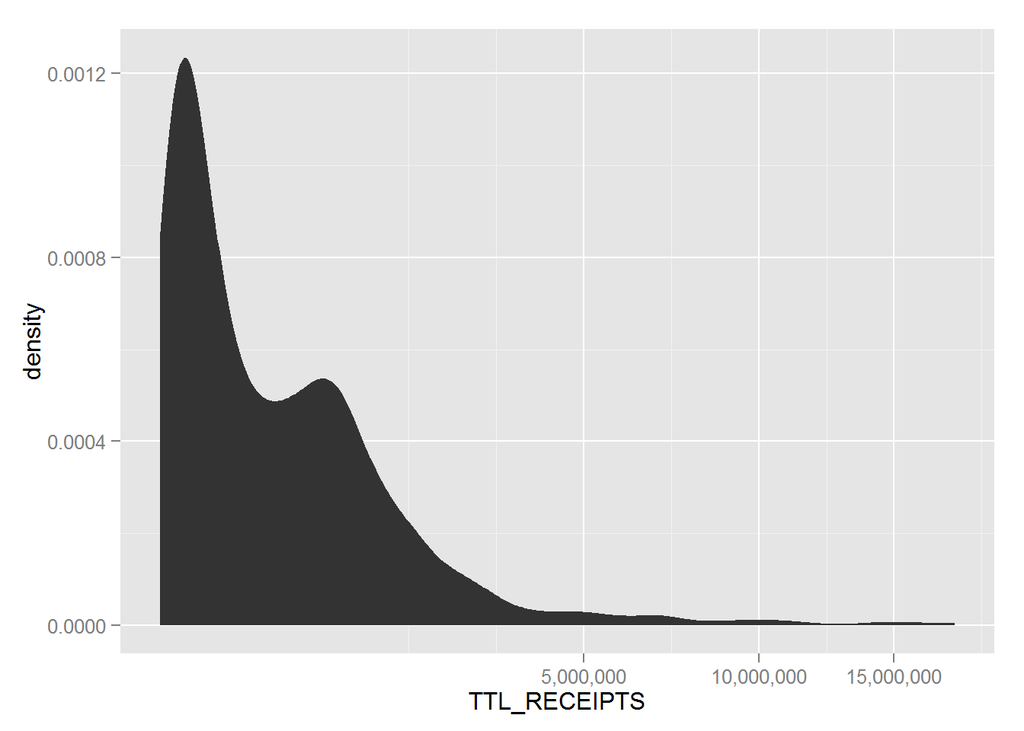

```r
library(ggplot2)
library(scales)  # needed for axis editing (non-scientific notation)
ggplot(df, aes(TTL_RECEIPTS)) + stat_density() + scale_x_sqrt(label = comma)
```

## Basic analysis

Let’s examine a scatterplot matrix to visually inspect some of the pairwise relationships between variables. Of potential interest are the various monetary variables, party affiliation, and general election percent (where applicable).

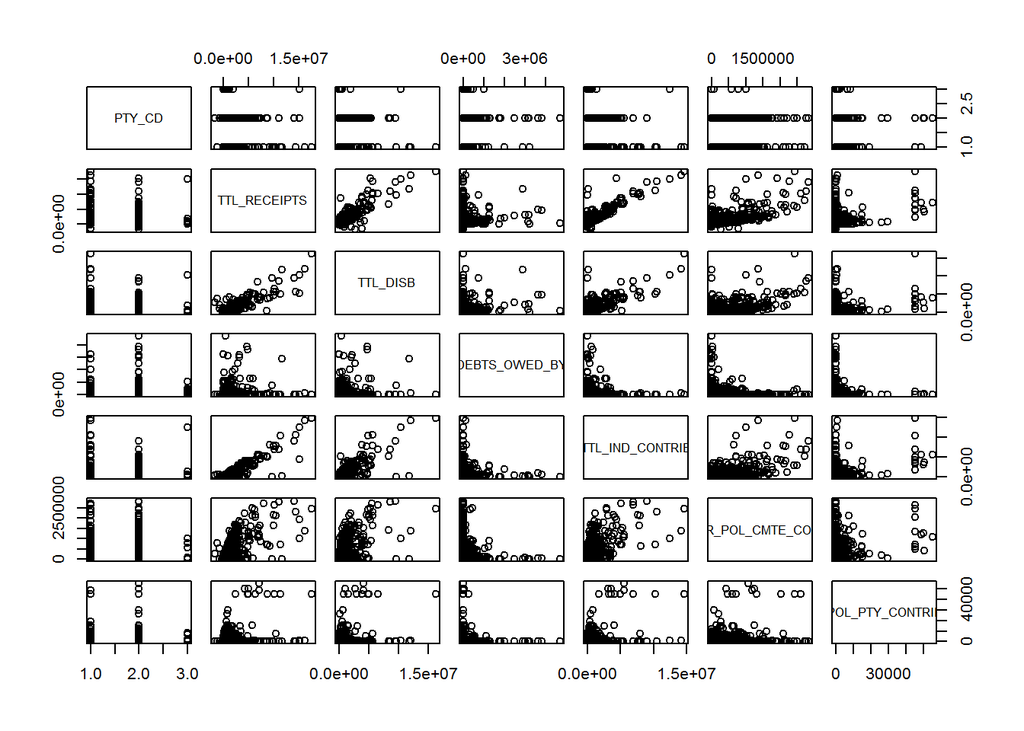

```r
df.pairs <- df %>%
  select(PTY_CD, TTL_RECEIPTS, TTL_DISB, DEBTS_OWED_BY, TTL_IND_CONTRIB,
         OTHER_POL_CMTE_CONTRIB, POL_PTY_CONTRIB)
pairs(df.pairs)
```

As you would expect, total receipts, total distributions, and individual contribution appear closely linearly related. There also appears to be a noiser and less pronounced linear relationship between total receipts and other political committee contribution–but surprisingly, political party contribution has what appears to be a more neutral or perhaps even downward quadratic relationship. However, there is no reason to suspect any collinearity or othher anomalies in the data. The only data which looks possibly suspect lies in the political party contribution variable–there appear to be a non-trivial number of observations that are bunched at exactly the roughly $45,000 mark:

```
## stat_bin: binwidth defaulted to range/30. Use 'binwidth = x' to adjust this.
```

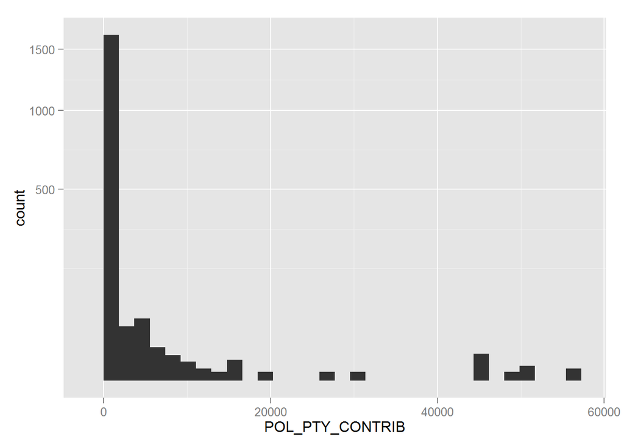

```r
ggplot(df.pairs, aes(POL_PTY_CONTRIB)) + geom_histogram() + scale_y_sqrt()
```

```r
# To get the exact number, we use the following:
nrow(df %>% filter(POL_PTY_CONTRIB >= 45000 & POL_PTY_CONTRIB < 47000))
```

```
## [1] 10
```

```r
# Putting this number into perspective:
nrow(df %>% filter(POL_PTY_CONTRIB > 25000))
```

```
## [1] 18
```